# Prediction Assignment Writeup

datasciencespm

Sunday, September 14, 2014

## Executive Summary

This report describes an analysis of a [weight lifting data set](http://groupware.les.inf.puc-rio.br/har) described in the following journal article:

Velloso, E.; Bulling, A.; Gellersen, H.; Ugulino, W.; Fuks, H. “[Qualitative Activity Recognition of Weight Lifting Exercises](http://groupware.les.inf.puc-rio.br/work.jsf?p1=11201)”. Proceedings of 4th International Conference in Cooperation with SIGCHI (Augmented Human ’13). Stuttgart, Germany: ACM SIGCHI, 2013.

that contains measurements from accelerometers placed on the:

- weight lifted (i.e. dumbbell)
- belt
- forearm
- arm

for six test participants. The results presented in this document will illustrate the process that I followed to:

1.) Load & clean the training and test data  
2.) Perform exploratory data analysis  
3.) Train a prediction algorithm (i.e. random forest)  
4.) Estimate the out-of-sample error  
5.) Apply the trained predictor to the test data set

The accuracy of the predictor that I will describe in this report is 70% based on scoring results generated by the [Coursera website](https://www.coursera.org/course/predmachlearn). My analysis of this result is that it is slightly lower than the average accuracy of 78.8% estimated from the [normalized confusion matrix](http://groupware.les.inf.puc-rio.br/har) shown on the bottom of the website that includes a description of this weight lifting dataset.

## Load & Clean Data

The first step required to generate clean training and test data is setting up the R programming environment that is illustrated in the following code chunk. This section of R code begins with [verifying that the required R packages](http://stackoverflow.com/questions/9341635/how-can-i-check-for-installed-r-packages-before-running-install-packages) are installed. Next, this software loads the required R packages prior to [setting global code chunk options](https://github.com/yihui/knitr/blob/master/inst/examples/knitr-minimal.Rmd).

```r
# Verify required packages are installed
required.packages <- c("caret",
                       "Gmisc",
                       "ggplot2",
                       "knitr",
                       "GGally",
                       "randomForest",
                       "RColorBrewer")

new.packages <- required.packages[!(required.packages %in%
                                    installed.packages())]

if(length(new.packages)) {
  install.packages(new.packages)
}

# Load required packages
library(caret)
library(Gmisc)
library(ggplot2)
library(knitr)
library(GGally)
library(randomForest)
library(RColorBrewer)

opts_chunk$set(cache=TRUE,
               cache.path = 'DocumentName_cache/',
               fig.path='figure/',
               tidy.opts=list(keep.blank.line=FALSE, width.cutoff=60),
               fig.width=7,
               fig.height=5)
```

The second step that I performed during the process of creating clean training and test data is loading these data sets into memory by calling the `loadExercsieData` function defined in the following code chunk. This function performs the following three operations:

1.) Removing “_“’s from variable names  
2.) Removing”.“’s from variable names  
3.) Combining the *rawtimestamppart1* and *rawtimestamppart2* variables into a [Unix time stamp](https://www.gnu.org/software/coreutils/manual/html_node/Seconds-since-the-Epoch.html)

```r
## ###########################################################################
## DEFINE FUNCTIONS
## ###########################################################################
loadExerciseData <- function(exerciseDataFile) {
#------------------------------------------------------------------------
# Loads a *.csv that contains training or testing data into memory.
# The operations performed by this function include:
# - Removing "_"'s from variable names
# - Removing "."'s from variable names
# - Combing the rawtimestamppart1 & rawtimestamppart2 variables into
#   a timestamp variable that represents the measurement time in the
#   Unix (i.e. "seconds since the epoch") format
#
# Args:
#   exerciseDataFile: String that stores the data file name
#
# Returns:
#   exerciseData: Data frame that contains weight lifting data
#
# Constraints:
#   This function assumes that the weight lifting data file is located
#   in the following relative path: ./Data
#------------------------------------------------------------------------
    if (!file.exists("./Data")) {
        dir.create("./Data")

        trainingDataURL <-
            paste0("https://d396qusza40orc.cloudfront.net/predmachlearn",
                   "/pml-training.csv")

        testDataURL <-
            paste0("https://d396qusza40orc.cloudfront.net/predmachlearn",
                   "/pml-testing.csv")

        download.file(trainingDataURL, destfile = "./Data/trainingData.csv")
        download.file(testDataURL, destfile = "./Data/testData.csv")
    }

    exerciseData <- read.csv(file = file.path("./Data",
                                              exerciseDataFile),
                             header=TRUE,
                             stringsAsFactors = FALSE)

    colnames(exerciseData) <- tolower(colnames(exerciseData))
    variableNames <- colnames(exerciseData)

    for (i in seq_len(length(variableNames))) {
        variableNames[i] <- gsub("_", "", variableNames[i])
        variableNames[i] <- gsub("\\.", "", variableNames[i])
    }

    colnames(exerciseData) <- variableNames

    exerciseData$timestamp <- exerciseData$rawtimestamppart1 +
                              exerciseData$rawtimestamppart2*1E-6

    exerciseData <-
        exerciseData[,!colnames(exerciseData) %in% c("x",
                                                     "rawtimestamppart1",
                                                     "rawtimestamppart2")]

    return(exerciseData)
}
## ###########################################################################
## ANALYSIS
## ###########################################################################
trainingData <- loadExerciseData("trainingData.csv")

testData <- loadExerciseData("testData.csv")
```

The number of rows in the training and test data is 19622 and 20, respectively. The third step that I performed to prepare this data for analysis is transforming it into [tidy data](http://vimeo.com/33727555). The key characteristic of this data transform is that the data set variables are contained a data frame columns and there is one observation per data frame row.

The purpose of `initializeDataWindowIndex()`, which is the first R function defined in the following code chunk, is to aggregate the time series data associated a specific individual and weight lifting motion class. Next, the second function defined in the following section of R software, `computeDataWindowCount()`, computes the number of time series window for each dumbbell exercise motion. Similarly, `computeDataWindowSize()` computes the size of each time series associated with a weight lifting motion class. Finally, `computeDataWindowSizeSummary()` computes a six-number summary:

- Minimum value
- 1st quantile
- Median
- Mean
- 3rd quantile
- Maximum

of the data window size for each dumbbell exercise motion. The rationale for writing these functions is that they simplified an initial exploratory analysis of the data.

```r
## ###########################################################################
## DEFINE FUNCTIONS
## ###########################################################################
initializeDataWindowIndex <- function(trainingData,
                                      minLength = 0,
                                      maxLength = NA) {
#------------------------------------------------------------------------
# Initializes a compound list that contains the data frame row indices
# corresponding to all time series windows in a weight lifting data set
#
# Required Args:
#   trainingData: Data frame that stores the training data
#
# Optional Args:
#   minLength: Integer that specifies the minimum number of data window
#              samples
#
#   maxLength: Integer that specifies the maximum number of data window
#              samples
#
# Returns:
#   dataWindow: Compound list that contains the data frame row indices
#               corresponding to all time series windows in a weight
#               lifting data set
#------------------------------------------------------------------------
    weightLiftingClasse <- unique(trainingData$classe)

    dataWindow <- list();
    for (curClasse in weightLiftingClasse) {
        dataWindow[[curClasse]] <- list();
    }

    startOfNewWindow <- which(trainingData$newwindow == "yes")

    numDataWindows <- length(startOfNewWindow)

    for (n in seq(0, numDataWindows)) {
        if (n == 0) {
            curWindowIdx <- 1:(startOfNewWindow[1] - 1)
        }
        else if (n == numDataWindows) {
            curWindowIdx <- startOfNewWindow[n]:nrow(trainingData)
        }
        else
        {
            curWindowIdx <- startOfNewWindow[n]:(startOfNewWindow[n + 1]- 1)
        }
        curClasse <- trainingData$classe[curWindowIdx[1]]

        minLengthTest <- length(curWindowIdx) >= minLength

        if (is.na(maxLength)) {
            maxLengthTest <- TRUE
        }
        else {
            maxLengthTest <- length(curWindowIdx) <= maxLength
        }

        if (minLengthTest & maxLengthTest) {
            dataWindow[[curClasse]][[length(dataWindow[[curClasse]]) + 1]] <-
                curWindowIdx
        }
    }

    return(dataWindow)
}

computeDataWindowCount <- function(dataWindow) {
#------------------------------------------------------------------------
# Computes the number of time series windows for each measurement classe
#
# Args:
#   dataWindow: Compound list that contains the data frame row indices
#               corresponding to all time series windows in a weight
#               lifting data set
#
# Returns:
#   dataWindowCount: Data frame that stores number of time series windows
#   for each measurement classe
#------------------------------------------------------------------------
    dataWindowCount <- data.frame()
    for (curClasse in names(dataWindow)) {
        dataWindowCount <- rbind(dataWindowCount,
                                 data.frame(classe=curClasse,
                                            count=length(dataWindow[[curClasse]])))
    }

    dataWindowCount$classe <- as.character(dataWindowCount$classe)

    return(dataWindowCount)
}

#------------------------------------------------------------------------
# Computes the size of each time series window contained in a weight
# lifting data set
#
# Args:
#   dataWindow: Compound list that contains the data frame row indices
#               corresponding to all time series windows in a weight
#               lifting data set
#
# Returns:
#   dataWindowSize: Data frame that stores the size of each time series
#   contained in a weight lifting data set
#------------------------------------------------------------------------
computeDataWindowSize <- function(dataWindow) {
    dataWindowSize <- data.frame()

    for (curClasse in names(dataWindow)) {
        for (curIdx in dataWindow[[curClasse]]) {
            dataWindowSize <-
                rbind(dataWindowSize,data.frame(classe=curClasse,
                                                windowsize=length(curIdx)))
        }
    }

    return(dataWindowSize)
}

computeDataWindowSizeSummary <- function(dataWindowSize) {
#----------------------------------------------------------------------
# Generates a data frame that stores a six number summary (i.e.
# minimum, 1st quantile, median, mean, 3rd quantile, and maximum)
# of time series window for each weight lifting measurement classe
#
# Args:
#   dataWindowSize: Data frame that stores the size of each time series
#   contained in a weight lifting data set
#
# Returns:
#   dataWindowSizeSummary: data frame that stores a six number summary
#   (i.e. minimum, 1st quantile, median, mean, 3rd quantile, and
#   maximum) of time series window for each weight lifting measurement
#   classe
#----------------------------------------------------------------------
    dataWindowSizeSummary <- data.frame()
    for (curClasse in unique(dataWindowSize$classe)) {
        curCounts <- subset(dataWindowSize,
                            dataWindowSize$classe==curClasse)

        curSummary <- summary(curCounts$windowsize)

        dataWindowSizeSummary <-
            rbind(dataWindowSizeSummary,
                  data.frame(classe=curClasse,
                             min=curSummary[1],
                             firstquantile=curSummary[2],
                             median=curSummary[3],
                             mean=curSummary[4],
                             thirdquantile=curSummary[5],
                             max=curSummary[6]))
    }
    rownames(dataWindowSizeSummary) <- NULL

    dataWindowSizeSummary$classe <- as.character(dataWindowSizeSummary$classe)

    return(dataWindowSizeSummary)
}
## ###########################################################################
## ANALYSIS
## ###########################################################################
dataWindow <- initializeDataWindowIndex(trainingData)
```

For example, the implementation of these R functions:

- `processNumericVariables()`
- `processCharacterVariables()`
- `initializeMeasurements()`

defined in the following code chunk are based on an initial exploratory data analysis during which I learned that this weight lifting data set contains scalar and time series measurements. The first two of these functions are called by `initializeMeasurements()`, which returns a compound list that contains:

- *cleanTrainingData*: Data frame where each row contains the measurements associated with a specific individual and dumbbell exercise motion
- *cleanDataWindow*: Compound list that contains the data frame row indices corresponding the clean training data measurements
- *ambiguousClasseDataWindow*: Compound list that contains the data frame row indices corresponding the time series windows where the dumbbell exercise motion class was ambiguous
- *characterVariables*: Character vector that stores the name of scalar variables associated with a specific individual and dumbbell exercise motion
- *numericVariables*: Character vector that stores the name of numeric time series variables associated with a specific individual and dumbbell exercise motion

This code chunk also contains two functions (i.e. `computePercentNAValues` and `computeNAValueStatistics` that I used to evaluate the percent of NA values contained in the weight lifting exercise training data set.

```r
## ###########################################################################
## DEFINE FUNCTIONS
## ###########################################################################
processNumericVariables <- function(curDataWindowIn,
                                    numericVariables) {
#----------------------------------------------------------------------
# Computes the mean of each time series numeric variable associated
# with a specific individual and dumbbell exercise motion class.
#
# ArgS:
#   curDataWindowIn: Data frame that contains the scalar and numeric
#                    time series measurements associated with a
#                    specific individual and dumbbell exercise motion
#                    class.
#
#   numericVariables: Character vector that stores the names of time
#                     series variables
#
# Returns:
#   curDataWindow: 1 row data frame that contains the mean of each time
#                  series numeric variable associated with a specific
#                  individual and dumbbell exercise motion class.
#----------------------------------------------------------------------
    numNumericVariables <- length(numericVariables)

    for (i in seq_len(numNumericVariables)) {
        curSamples <- curDataWindowIn[,numericVariables[i]]

        numValidSamples <- sum(!is.na(curSamples))

        if (numValidSamples == 1) {
            curNumericVariable <-
                data.frame(curSamples[!is.na(curSamples)])
        }
        else {
            curNumericVariable <- data.frame(mean(curSamples))
        }
        colnames(curNumericVariable) <- numericVariables[i]

         if (i == 1) {
             curDataWindow <- curNumericVariable
         }
         else {
             curDataWindow <- cbind(curDataWindow, curNumericVariable)
         }
    }

    return(curDataWindow)
}

processCharacterVariables <- function(curDataWindowIn,
                                      characterVariables) {
#----------------------------------------------------------------------
# Converts a scalar measurement associated with a specific individual
# and dumbbell exercise motion class to a numeric value.
#
# ArgS:
#   curDataWindowIn: Data frame that contains the scalar and numeric
#                    time series measurements associated with a
#                    specific individual and dumbbell exercise motion
#                    class.
#
#   characterVariables: Character vector that stores the names of scalar
#                       variables
#
# Returns:
#   curDataWindow: 1 row data frame that contains the numeric value of
#                  each sclar variable associated with a specific
#                  individual and dumbbell exercise motion class.
#----------------------------------------------------------------------
    numCharacterVariables <- length(characterVariables)

    #---------------------------------------------------------
    for (i in seq_len(numCharacterVariables)) {
        curVar <- characterVariables[i]
        curSamples <- suppressWarnings(as.numeric(curDataWindowIn[,curVar]))

        validIdx = which(!is.na(curSamples))

        numValidSamples <- length(validIdx)

        if (numValidSamples > 0) {
            curCharacterVariable <- data.frame(median(curSamples[validIdx]))
        }
        else {
            curCharacterVariable <- data.frame(NA)
        }
        colnames(curCharacterVariable) <- characterVariables[i]

        if (i == 1) {
            curDataWindow = curCharacterVariable
        }
        else {
            curDataWindow <- cbind(curDataWindow, curCharacterVariable)
        }
    }

    return(curDataWindow)
}

initializeMeasurements <- function(trainingData,
                                   dataWindow) {
#----------------------------------------------------------------------
# Initializes a compound list that stores the following attributes:
#
# - cleanTrainingData: Data frame where each row contains the
#                      measurements associated with a specific
#                      individual and dumbbell exercise motion
#
# - cleanDataWindow: Compound list that contains the data frame row
#                    indices corresponding the clean training data
#                    measurements
#
# - ambiguousClasseDataWindow: Compound list that contains the data
#                              frame row indices corresponding the
#                              time series windows where the dumbbell
#                              exercise motion class was ambiguous
#
# - characterVariables: Character vector that stores the name of
#                       scalar variables associated with a specific
#                       individual and dumbbell exercise motion
#
# - numericVariables: Character vector that stores the name of
#                     numeric time series variables associated with
#                     a specific individual and dumbbell exercise
#                     motion
#
# Args:
#   trainingData: Data frame that stores the raw training data
#
#   dataWindow: Compound list that contains the data frame row indices
#               corresponding to all time series windows in a weight
#               lifting data set
#
# Returns:
#   Compound list that stores clean training data and data cleaning
#   debug parameters
#----------------------------------------------------------------------
    cleanData <- list()
    ambiguousClasseDataWindow <- list()
    incompleteCaseDataWindow <- list()
    cleanDataWindow <- list()
    cleanTrainingData <- data.frame()

    characterVariables <- vector()
    numericVariables <- vector()

    for (i in seq_len(length(variableNames))) {
        curClass <- class(trainingData[,variableNames[i]])
        if (curClass == "character") {
            characterVariables <- c(characterVariables, variableNames[i])
        }
        else if (curClass == "numeric" | curClass == "integer") {
            numericVariables <- c(numericVariables, variableNames[i])
        }
    }

    for (curClasse in names(dataWindow)) {
        dataWindowNumber <- 1

        for (curDataWindowIdx in dataWindow[[curClasse]]) {
            curDataWindowIn <- trainingData[curDataWindowIdx,]

            numUniqueClasse <- length(unique(curDataWindowIn$classe))

            #-----------------------------------------------------------------
            if (numUniqueClasse == 1) {
                curDataWindow <- processNumericVariables(curDataWindowIn,
                                                         numericVariables)

                curDataWindow <-
                    cbind(curDataWindow,
                          processCharacterVariables(curDataWindowIn,
                                                    characterVariables))

                curDataWindow$datawindownumber <- dataWindowNumber

                curDataWindow$windowsize <- length(curDataWindowIdx)

                curDataWindow$classe <- curDataWindowIn$classe[1]

                n <- length(cleanDataWindow[[curClasse]]) + 1

                cleanDataWindow[[curClasse]][[n]] <- curDataWindowIdx

                cleanTrainingData <- rbind(cleanTrainingData,
                                           curDataWindow)

                dataWindowNumber <- dataWindowNumber + 1
            }
            #-----------------------------------------------------------------
            else {
                n <- length(ambiguousClasseDataWindow[[curClasse]]) + 1

                ambiguousClasseDataWindow[[curClasse]][[n]] <-
                    curDataWindowIdx
            }
        }
    }

    cleanData[[1]] <- cleanTrainingData
    cleanData[[2]] <- cleanDataWindow
    cleanData[[3]] <- ambiguousClasseDataWindow
    cleanData[[4]] <- characterVariables
    cleanData[[5]] <- numericVariables

    return(cleanData)
}

computePercentNAValues <- function(predictionData) {
#----------------------------------------------------------------------
# Determines the percent of NA values for each variable in a training
# or test dat set.
#
# Args:
#   predictionData: Data frame that contains training or test data
#
# Returns:
#   percentNAValues: Data frame that describes percent of NA values
#   for each variable in a training or test dat set.
#----------------------------------------------------------------------
    variableNames <- colnames(predictionData)

    percentNAValues <- vector('numeric',length(variableNames))

    for (i in seq_len(length(percentNAValues))) {
        percentNAValues[i] <-
            sum(is.na(predictionData[,variableNames[i]]))
    }

    percentNAValues <- 100 * (percentNAValues / nrow(predictionData))
    percentNAValues <- data.frame(percentnavalues=percentNAValues)
    percentNAValues$variable <- variableNames

    return(percentNAValues)
}

computeNAValueStatistics <- function(percentNAValues) {
#----------------------------------------------------------------------
# Computes the frequency of each % NA values region, which is a factor
# variable generated by the cut2() function applied to the continuous
# percentnavalues variable
#
# Args:
#   percentNAValues: Data frame that describes percent of NA values
#   for each variable in a training or test dat set.
#
# Returns:
#   percentNAValuesRegions: Data frame that describes the frequency of
#   each % NA values region, which is a factor variable generated by
#   the cut2() function applied to the continuous percentnavalues
#   variable.
#----------------------------------------------------------------------
    percentNAValuesRegions <- as.data.frame(table(percentNAValues$region))

    colnames(percentNAValuesRegions) <- c("region",
                                          "frequency")

    percentNAValuesRegions$region <-
        as.character(percentNAValuesRegions$region)

    return(percentNAValuesRegions)
}
## ###########################################################################
## ANALYSIS
## ###########################################################################
variableNames <- colnames(trainingData)

variableNames <- variableNames[!variableNames %in% c("username",
                                                     "cvtdtimestamp",
                                                     "newwindow",
                                                     "numwindow",
                                                     "classe",
                                                     "timestamp")]

cleanData <- initializeMeasurements(trainingData,
                                    dataWindow)
rm(trainingData)

cleanTrainingData <- cleanData[[1]]
cleanDataWindow <- cleanData[[2]]
ambiguousClasseDataWindow <- cleanData[[3]]
characterVariables <- cleanData[[4]]
numericVariables <- cleanData[[5]]
rm(cleanData)
```

Once the initialization of the clean training data is complete, the following R code chunk illustrates that I evaluated the percentage of missing values for each variable by performing the following procedure:

1.) Compute the percent of variable NA values  
2.) Apply the [`cut2`](http://www.inside-r.org/packages/cran/Hmisc/docs/cut2) function to divide the percentnavalues into five regions  
3.) Compute the frequency of each percentnavalues variable region  
4.) Display the variable NA value statistics using the [`htmlTable`](http://gforge.se/2014/01/fast-track-publishing-using-knitr-part-iv) function.

```r
percentNAValues <- computePercentNAValues(cleanTrainingData)

percentNAValues$region <- cut2(percentNAValues$percentnavalues,
                               cuts=c(1.5,5,15,50))

percentNAValuesRegions <- computeNAValueStatistics(percentNAValues)

htmlTable(percentNAValuesRegions,
          caption="Table #1: Training % NA Value Statistics",
          align=c("c","c"),
          rowlabel="",)
```

| Table #1: Training % NA Value Statistics | Table #1: Training % NA Value Statistics region | Table #1: Training % NA Value Statistics frequency |
| --- | --- | --- |
| 1 | [ 0.0, 1.5) | 129 |
| 2 | [ 1.5, 5.0) | 7 |
| 3 | [ 5.0, 15.0) | 2 |
| 4 | [ 15.0, 50.0) | 11 |
| 5 | [ 50.0,100.0] | 6 |

The results shown in table #1 suggest that most of the clean training data variables have a low number of (i.e. less than 5%) missing values.

```r
percentVariablesExcluded =
    100 * sum(percentNAValuesRegions[percentNAValuesRegions$region %in%
                                     c("[  5.0, 15.0)",
                                       "[ 15.0, 50.0)",
                                       "[ 50.0,100.0]"),c("frequency")]) /
          sum(percentNAValuesRegions$frequency)

percentVariablesExcluded <- round(percentVariablesExcluded, digits=1)
```

The percentage of variables removed due to NA values based on this threshold is 12.3 %. Next, the following code chunk segments the clean training data based on this threshold. My rationale for applying this threshold is that dumbbell exercise motion measurements containing a large number of missing values may bias the predictor training. The following R software also generates a [`htmlTable`](http://gforge.se/2014/01/fast-track-publishing-using-knitr-part-iv) (i.e. table #2) that describes the nineteen measurements removed due a high percentage (i.e. >= 5%) of missing values. This R code chunk also removes the following variables:

- *cusername*
- *cvtdtimestamp*
- *newwindow*
- *numwindow*
- *timestamp*

that are not required to train a predictor. My rationale for this additional segmentation of the clean training data is that these variables do not provide insight regarding the type of dumbbell exercise motion performed by an individual.

```r
excluedVariables <-
    percentNAValues[which(percentNAValues$percentnavalues >= 5.0),]

excluedVariables$region <- as.character(excluedVariables$region)
rownames(excluedVariables) <- NULL

excluedVariables$percentnavalues <-
    round(excluedVariables$percentnavalues, digits=1)

htmlTable(excluedVariables,
          caption="Table #2: Excluded Variables Based on % of NA Values",
          align = c("c","c","c"),
          rowlabel="")
```

| Table #2: Excluded Variables Based on % of NA Values | Table #2: Excluded Variables Based on % of NA Values percentnavalues | Table #2: Excluded Variables Based on % of NA Values variable | Table #2: Excluded Variables Based on % of NA Values region |
| --- | --- | --- | --- |
| 1 | 7.7 | kurtosispicthbelt | [ 5.0, 15.0) |
| 2 | 100 | kurtosisyawbelt | [ 50.0,100.0] |
| 3 | 7.7 | skewnessrollbelt1 | [ 5.0, 15.0) |
| 4 | 100 | skewnessyawbelt | [ 50.0,100.0] |
| 5 | 19.4 | kurtosisrollarm | [ 15.0, 50.0) |
| 6 | 19.9 | kurtosispictharm | [ 15.0, 50.0) |
| 7 | 19.4 | skewnessrollarm | [ 15.0, 50.0) |
| 8 | 19.9 | skewnesspitcharm | [ 15.0, 50.0) |
| 9 | 100 | kurtosisyawdumbbell | [ 50.0,100.0] |
| 10 | 100 | skewnessyawdumbbell | [ 50.0,100.0] |
| 11 | 20.8 | kurtosisrollforearm | [ 15.0, 50.0) |
| 12 | 21.1 | kurtosispicthforearm | [ 15.0, 50.0) |
| 13 | 100 | kurtosisyawforearm | [ 50.0,100.0] |
| 14 | 20.8 | skewnessrollforearm | [ 15.0, 50.0) |
| 15 | 21.1 | skewnesspitchforearm | [ 15.0, 50.0) |
| 16 | 100 | skewnessyawforearm | [ 50.0,100.0] |
| 17 | 20.8 | maxyawforearm | [ 15.0, 50.0) |
| 18 | 20.8 | minyawforearm | [ 15.0, 50.0) |
| 19 | 20.8 | amplitudeyawforearm | [ 15.0, 50.0) |

The purpose of the following R code chunk is to implement this analysis approach prior to evaluating the number of time series samples associated with each weight lifting exercise measurement.

```r
cleanTrainingData <-
    cleanTrainingData[,!colnames(cleanTrainingData) %in%
                                 excluedVariables$variable]

cleanTrainingData <-
    cleanTrainingData[complete.cases(cleanTrainingData),]

cleanTrainingData <-
    cleanTrainingData[,!colnames(cleanTrainingData) %in%
                                 c("username",
                                   "cvtdtimestamp",
                                   "newwindow",
                                   "numwindow",
                                   "timestamp")]
```

The results shown in table #3 (that is generated by the following R code chunk) suggest that size of most weight lifting measurement data time series windows falls between 20 and 130.

```r
## ###########################################################################
## DEFINE FUNCTIONS
## ###########################################################################
initializeCleanDataWindowSizeSummary <- function(cleanTrainingData) {
#----------------------------------------------------------------------
# Computes a six-number summary (i.e. mininum, 1st quantile, median,
# mean, 3rd quantile, & maximum) of the size of time series windows
# associated with a specific dumbbell exercise motion
#
# Args:
#   cleanTrainingData: Data frame that stores clean training data
#
# Returns:
#   dataWindowSizeSummary: Data frame that contains a six-number summary
#                          (i.e. mininum, 1st quantile, median, mean,
#                          3rd quantile, & maximum) of the size of time
#                          series windows associated with a specific
#                          dumbbell exercise motion
#----------------------------------------------------------------------
    dataWindowSizeSummary <- data.frame()

    for (curClasse in unique(cleanTrainingData$classe)) {
        curWindowsize <-
            cleanTrainingData[which(cleanTrainingData$classe==curClasse),
                              c("windowsize")]

        curSummary <- summary(curWindowsize)

        dataWindowSizeSummary <-
            rbind(dataWindowSizeSummary,
                  data.frame(classe=curClasse,
                             min=curSummary[1],
                             firstquantile=curSummary[2],
                             median=curSummary[3],
                             mean=curSummary[4],
                             thirdquantile=curSummary[5],
                             max=curSummary[6]))
    }
    rownames(dataWindowSizeSummary) <- NULL

    dataWindowSizeSummary$classe <-
        as.character(dataWindowSizeSummary$classe)

    return(dataWindowSizeSummary)
}
## ###########################################################################
## ANALYSIS
## ###########################################################################
dataWindowSizeSummary <-
    initializeCleanDataWindowSizeSummary(cleanTrainingData)

htmlTable(dataWindowSizeSummary,
          caption="Table #3: Original Data Window Size Statistics",
          rowlabel="",)
```

| Table #3: Original Data Window Size Statistics | Table #3: Original Data Window Size Statistics classe | Table #3: Original Data Window Size Statistics min | Table #3: Original Data Window Size Statistics firstquantile | Table #3: Original Data Window Size Statistics median | Table #3: Original Data Window Size Statistics mean | Table #3: Original Data Window Size Statistics thirdquantile | Table #3: Original Data Window Size Statistics max |
| --- | --- | --- | --- | --- | --- | --- | --- |
| 1 | A | 2 | 25 | 41 | 50.3 | 62 | 298 |
| 2 | B | 12 | 24 | 30 | 46.6 | 55.2 | 337 |
| 3 | C | 15 | 25.8 | 45.5 | 48.3 | 68 | 114 |
| 4 | D | 15 | 24 | 32 | 45.9 | 57.5 | 134 |
| 5 | E | 1 | 22.2 | 38.5 | 44.9 | 54 | 125 |

Therefore, I evaluate the resulting statistics of the further segmenting the clean training data based on applying these thresholds. The following R code implements this procedure via these operations:

- Aggreage the *windowsize* variable into four regions using the [`cut2`](http://www.inside-r.org/packages/cran/Hmisc/docs/cut2) function
- Compute the frequency of the resulting *windowsizeregion* factor variable
- Summarize these results in a table
- Compute the percent of clean training data excluded based on time series window size

```r
cleanTrainingData$windowsizeregion <- cut2(cleanTrainingData$windowsize,
                                           cuts=c(20,70,130))

windowsizeregion <- as.data.frame(table(cleanTrainingData$windowsizeregion))
colnames(windowsizeregion) <- c("windowsizeregion","frequency")
windowsizeregion$windowsizeregion <-
    as.character(windowsizeregion$windowsizeregion)

htmlTable(windowsizeregion,
          caption="Table #4: Training Data Window Size Statistics",
          align=c("c","c"),
          rowlabel="",)
```

| Table #4: Training Data Window Size Statistics | Table #4: Training Data Window Size Statistics windowsizeregion | Table #4: Training Data Window Size Statistics frequency |
| --- | --- | --- |
| 1 | [ 1, 20) | 39 |
| 2 | [ 20, 70) | 265 |
| 3 | [ 70,130) | 70 |
| 4 | [130,337] | 7 |

```r
exlcudedWindowSize <-
    windowsizeregion[windowsizeregion$windowsizeregion %in%
                     c("[  1, 20)","[130,337]"),]

percentExcludedData <-
    round(100*(sum(exlcudedWindowSize$frequency) /
          sum(windowsizeregion$frequency)), digits=1)
```

My analysis of the data window size statistics computed by the above R code chunk suggest that the percent of training data excluded based on data window size is 12.1 %. The initial data window statistics shown in figure #1 also illustrate the asymmetric data window size statistics summarized in table #4.

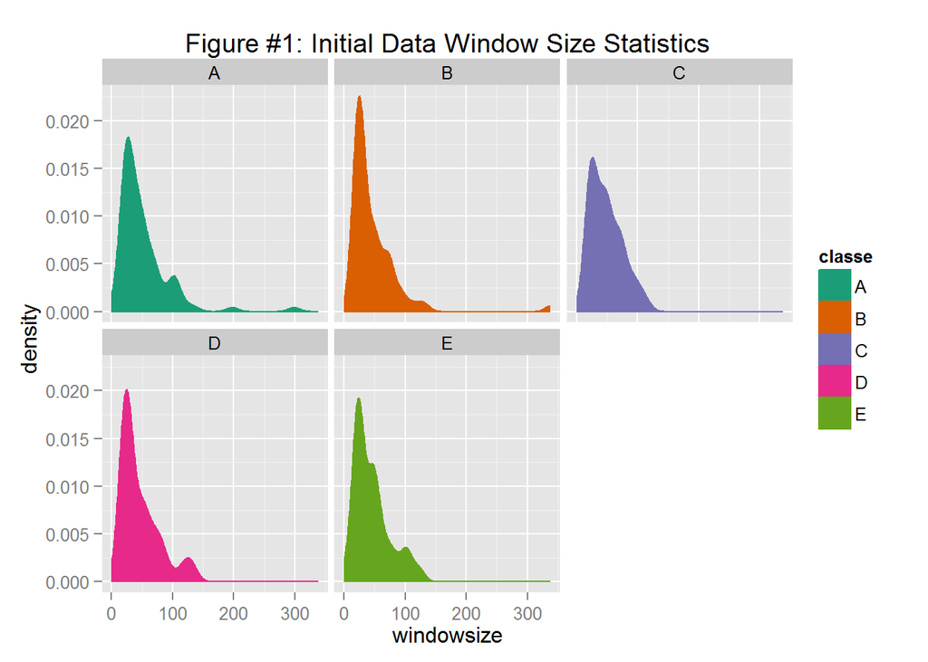

```r
ggplot(cleanTrainingData, aes(x=windowsize, colour=classe, fill=classe)) +
      geom_density() + scale_colour_brewer(palette="Dark2") +
      scale_fill_brewer(palette="Dark2") +
      facet_wrap(~classe) +
      ggtitle("Figure #1: Initial Data Window Size Statistics")
```

The purpose of the following R software is to first segment the clean training data based on time series window size. The second operation performed by this R software is generating a visualization of the refined time series window size shown in figure #2. My analysis of these results is that segmenting the clean training data based on time series window size balances the distribution of time series window sizes across all five different dumbbell exercise motion classes. The third operation performed by this R software is computing a six number summary of the resulting time series window size that is consistent with the results shown in figure #2.

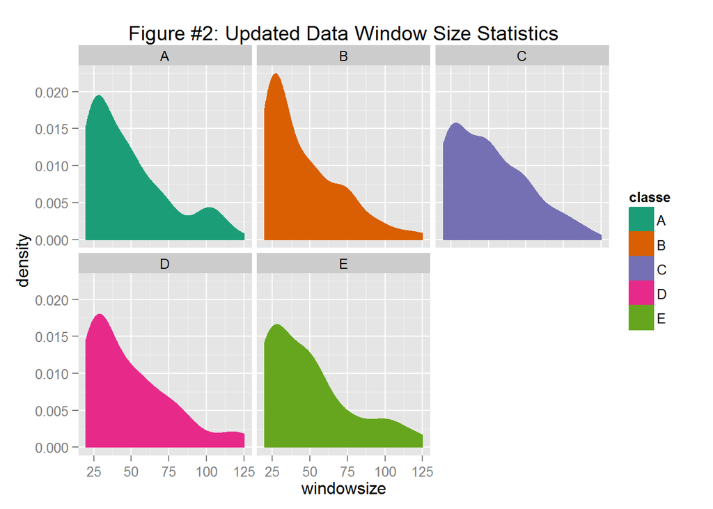

```r
cleanTrainingData <-
    cleanTrainingData[cleanTrainingData$windowsizeregion %in%
                      c("[ 20, 70)","[ 70,130)"),]

ggplot(cleanTrainingData, aes(x=windowsize, colour=classe, fill=classe)) +
      geom_density() + scale_colour_brewer(palette="Dark2") +
      scale_fill_brewer(palette="Dark2") +
      facet_wrap(~classe) +
      ggtitle("Figure #2: Updated Data Window Size Statistics")
```

```r
dataWindowSizeSummary <-
    initializeCleanDataWindowSizeSummary(cleanTrainingData)

htmlTable(dataWindowSizeSummary,
          caption="Table #5: Updated Data Window Size Statistics",
          align=c("c","c","c","c","c","c","c"),
          rowlabel="")
```

| Table #5: Updated Data Window Size Statistics | Table #5: Updated Data Window Size Statistics classe | Table #5: Updated Data Window Size Statistics min | Table #5: Updated Data Window Size Statistics firstquantile | Table #5: Updated Data Window Size Statistics median | Table #5: Updated Data Window Size Statistics mean | Table #5: Updated Data Window Size Statistics thirdquantile | Table #5: Updated Data Window Size Statistics max |
| --- | --- | --- | --- | --- | --- | --- | --- |
| 1 | A | 20 | 27 | 42 | 47.7 | 61 | 121 |
| 2 | B | 20 | 25 | 33 | 44.9 | 56 | 122 |
| 3 | C | 20 | 26 | 48 | 50.3 | 71 | 114 |
| 4 | D | 20 | 26 | 36.5 | 48.1 | 64 | 123 |
| 5 | E | 20 | 25 | 45 | 49 | 63 | 125 |

Next, I remove the following variables:

- *windowsizeregion*
- *windowsize*
- *datawindownumber*

from the clean training data that are not required to train a predictor. My rationale for this analysis approach is that it simplifies the formula input parameter for the [caret package](http://topepo.github.io/caret/training.html).

```r
cleanTrainingData <-
    cleanTrainingData[!colnames(cleanTrainingData) %in% c("windowsizeregion",
                                                          "windowsize",
                                                          "datawindownumber")]

cleanTrainingData$classe <- as.factor(cleanTrainingData$classe)

rownames(cleanTrainingData) <- NULL

variableNames <- colnames(cleanTrainingData)
```

The final step that I performed to prepare the training and test data for analysis was evaluating the percent of NA variables in the test data. The results shown in table #6 suggest that each variable in the test data falls into one of the following groups:

- 0% missing values
- 0.1%-100% missing values

```r
percentTestDataNAVariables <- computePercentNAValues(testData)

percentTestDataNAVariables$region <-
    cut2(percentTestDataNAVariables$percentnavalues, cuts=c(0.1))

percentTestDataNAValuesRegions <-
    computeNAValueStatistics(percentTestDataNAVariables)

htmlTable(percentTestDataNAValuesRegions,
          caption="Table #6: Test Data % NA Value Statistics",
          align=c("c","c"),
          rowlabel="",)
```

| Table #6: Test Data % NA Value Statistics | Table #6: Test Data % NA Value Statistics region | Table #6: Test Data % NA Value Statistics frequency |
| --- | --- | --- |
| 1 | 0.0 | 58 |
| 2 | [ 0.1,100.0] | 100 |

Therefore, in order to avoid an error when calling caret package `train` function, the following R code chunk:

1.) Removes test data variables that have at least one missing value  
2.) Removes test variables that will not be processed in order to estimate the dumbbell exercise movement class  
3.) Removes training data variables that are not completed defined in the test data.

```r
validTestVariableIdx <- which(percentTestDataNAVariables$percentnavalues == 0)

validTestVariables <-
    percentTestDataNAVariables[validTestVariableIdx,c("variable")]

validTestVariables <-
    validTestVariables[!validTestVariables %in% c("username",
                                                  "cvtdtimestamp",
                                                  "newwindow",
                                                  "numwindow",
                                                  "problemid",
                                                  "timestamp")]

cleanTrainingData <-
    cleanTrainingData[,colnames(cleanTrainingData) %in%
                                c(validTestVariables,"classe")]
```

## Exploratory Data Analysis

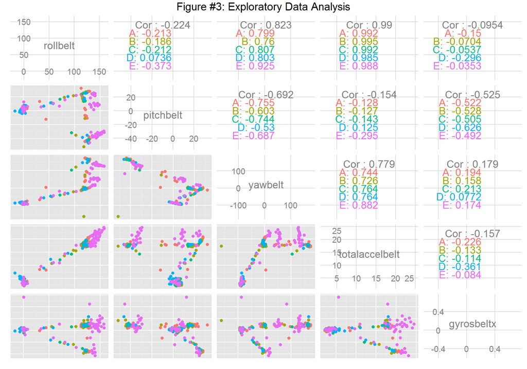

```r
ggpairs(data=cleanTrainingData,
        columns=1:5,
        colour='classe',
        title="Figure #3: Exploratory Data Analysis")
```

## Train Predictor

```r
seedValue <- 33833
set.seed(seedValue)
randomForestModel1Fit <- train(classe ~ .,
                               data=cleanTrainingData,
                               method="rf",
                               strata=cleanTrainingData$classe)

print(randomForestModel1Fit$finalModel)
```

```
##
## Call:
##  randomForest(x = x, y = y, mtry = param$mtry, strata = ..1)
##                Type of random forest: classification
##                      Number of trees: 500
## No. of variables tried at each split: 2
##
##         OOB estimate of  error rate: 17.31%
## Confusion matrix:
##    A  B  C  D  E class.error
## A 81  2  2  2  0     0.06897
## B 10 49  4  0  2     0.24615
## C  7  5 52  0  0     0.18750
## D  1  1  7 37  4     0.26000
## E  1  7  1  2 58     0.15942
```

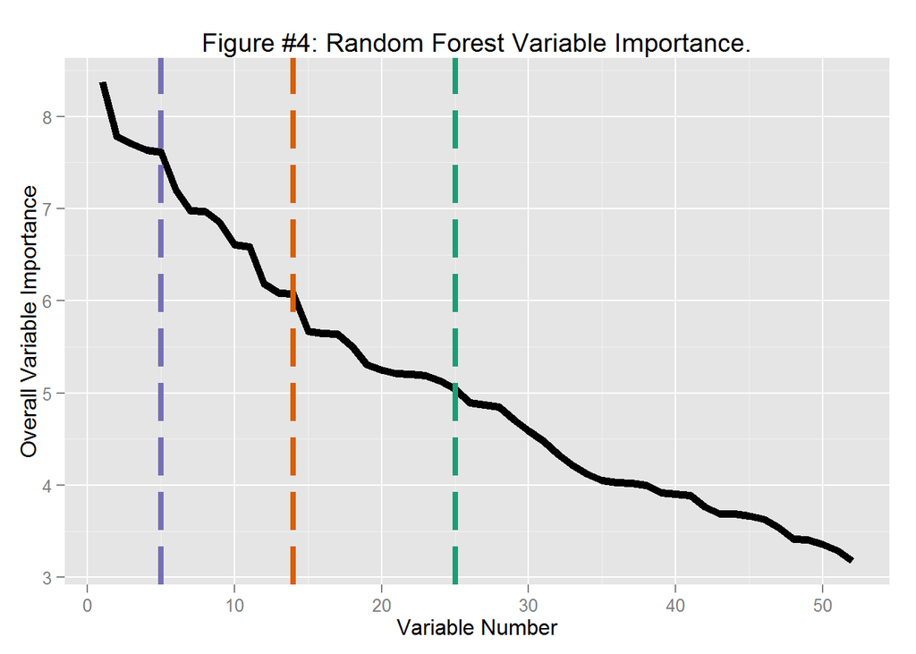

```r
numModelErrorRows1 <- nrow(randomForestModel1Fit$finalModel$err.rate)
outOfSampleErrorRate1 <-
    round(randomForestModel1Fit$finalModel$err.rate[numModelErrorRows1,1],
          digits=3)*100

variableImportanace <- varImp(randomForestModel1Fit$finalModel)
variableImportanace$variable <- rownames(variableImportanace)
rownames(variableImportanace) <- NULL
colnames(variableImportanace) <- c("overallimportance",
                                   "variable")

variableImportanace <- variableImportanace[,c(2,1)]

variableImportanace <-
    variableImportanace[order(variableImportanace$overallimportance,
                              decreasing = TRUE),]

rownames(variableImportanace) <- NULL

variableImportanace$variablenum <- 1:nrow(variableImportanace)

p <- brewer.pal(n=3,"Dark2")

ggplot(variableImportanace,
       aes(x=variablenum,y=overallimportance)) + geom_line(size=2) +
    xlab("Variable Number") + ylab("Overall Variable Importance") +
    geom_vline(xintercept=25,colour=p[1], linetype = "longdash", size=1.5) +
    geom_vline(xintercept=14,colour=p[2], linetype = "longdash", size=1.5) +
    geom_vline(xintercept=5,colour=p[3], linetype = "longdash", size=1.5) +
    ggtitle("Figure #4: Random Forest Variable Importance.")
```

For example, the random forest final model printed by the above R chunk includes an estimated out-of-sample error of 17.3 %. The figure generated by the above R code chunk (i.e. Figure #4) also highlights three different segmentation of the variable importance that I evaluated in order arrive at the final model.

```r
rf2Idx <- seq(1:25)

cleanTrainingData2 <-
    cleanTrainingData[,colnames(cleanTrainingData) %in%
                       c(variableImportanace$variable[rf2Idx],"classe")]

set.seed(seedValue)
randomForestModel2Fit <- train(classe ~ .,
                               data=cleanTrainingData2,
                               method="rf",
                               strata=cleanTrainingData2$classe)

numModelErrorRows2 <- nrow(randomForestModel2Fit$finalModel$err.rate)
outOfSampleErrorRate2 <-
    round(randomForestModel2Fit$finalModel$err.rate[numModelErrorRows2,1],
          digits=3)*100

print(randomForestModel2Fit$finalModel)
```

```
##
## Call:
##  randomForest(x = x, y = y, mtry = param$mtry, strata = ..1)
##                Type of random forest: classification
##                      Number of trees: 500
## No. of variables tried at each split: 2
##
##         OOB estimate of  error rate: 13.43%
## Confusion matrix:
##    A  B  C  D  E class.error
## A 80  3  2  1  1     0.08046
## B  7 51  3  2  2     0.21538
## C  3  5 55  0  1     0.14062
## D  2  2  2 43  1     0.14000
## E  0  5  0  3 61     0.11594
```

The results of evaluating the above R code section suggest that training a random forest model with the top twenty-five variables arranged based on overall importance is 13.4 %.

```r
rf3Idx <- seq(1:14)

cleanTrainingData3 <-
    cleanTrainingData[,colnames(cleanTrainingData) %in%
                       c(variableImportanace$variable[rf3Idx],"classe")]

set.seed(seedValue)
randomForestModel3Fit <- train(classe ~ .,
                               data=cleanTrainingData3,
                               method="rf",
                               strata=cleanTrainingData3$classe)

numModelErrorRows3 <- nrow(randomForestModel3Fit$finalModel$err.rate)
outOfSampleErrorRate3 <-
    round(randomForestModel3Fit$finalModel$err.rate[numModelErrorRows3,1],
          digits=3)*100

print(randomForestModel3Fit$finalModel)
```

```
##
## Call:
##  randomForest(x = x, y = y, mtry = param$mtry, strata = ..1)
##                Type of random forest: classification
##                      Number of trees: 500
## No. of variables tried at each split: 2
##
##         OOB estimate of  error rate: 13.13%
## Confusion matrix:
##    A  B  C  D  E class.error
## A 82  3  2  0  0     0.05747
## B  6 53  3  2  1     0.18462
## C  1  6 56  0  1     0.12500
## D  2  3  2 42  1     0.16000
## E  0  4  2  5 58     0.15942
```

Similarly, the output of the above R code chunk implies that the out-of-sample error is 13.1 % when a random forest predictor is trained with top fourteen variables sorted based on overall importance.

```r
rf4Idx <- seq(1:5)

cleanTrainingData4 <-
    cleanTrainingData[,colnames(cleanTrainingData) %in%
                       c(variableImportanace$variable[rf4Idx],"classe")]

set.seed(seedValue)
randomForestModel4Fit <- train(classe ~ .,
                               data=cleanTrainingData4,
                               method="rf",
                               strata=cleanTrainingData4$classe)

numModelErrorRows4 <- nrow(randomForestModel4Fit$finalModel$err.rate)
outOfSampleErrorRate4 <-
    round(randomForestModel4Fit$finalModel$err.rate[numModelErrorRows4,1],
          digits=3)*100

print(randomForestModel4Fit$finalModel)
```

```
##
## Call:
##  randomForest(x = x, y = y, mtry = param$mtry, strata = ..1)
##                Type of random forest: classification
##                      Number of trees: 500
## No. of variables tried at each split: 2
##
##         OOB estimate of  error rate: 22.39%
## Confusion matrix:
##    A  B  C  D  E class.error
## A 70  5  9  3  0      0.1954
## B  6 44 10  4  1      0.3231
## C  5  7 50  0  2      0.2188
## D  4  3  1 39  3      0.2200
## E  1  6  0  5 57      0.1739
```

Finally, the output of the above section of R software suggests that the out-of-sample error is 22.4 for training a random forest with the top five variables ordered based on overall importance. Therefore, these training results suggest that training a random forest model with either the top fourteen or top twenty five variables sorted based on overall importance yield similar results.

# Apply Predictor to test data

The following section of R code applies a predictor previously trained using the top twenty-five important variables. Next, it writes these results to individual text files. The accuracy of this predictor is 70% based on scoring results generated by the [Coursera website](https://www.coursera.org/course/predmachlearn). My analysis of this result is that it is slightly lower than the average accuracy of 78.8% estimated from the [normalized confusion matrix](http://groupware.les.inf.puc-rio.br/har) shown on the bottom of the website that includes a description of this weight lifting dataset.

```r
pml_write_files = function(predClasse){
#----------------------------------------------------------------------
# Writes prediction results to a folder in order to simplify uploading
# them to the Coursera website
#
# Args:
#   predClasse: Character vector that contains the predicted classes
#               for the test data set.
#
# Returns:
#   None
#
# Technical Reference: Example code provided by Dr. Jeffrey Leek in
#                      the Practical Machine Learning Coursera
#                      project submission instructions webpage
#----------------------------------------------------------------------
    resultsFolder = "./predictionResults"

    if (!file.exists(resultsFolder)) {
        dir.create(resultsFolder)
    }

    x <- as.character(predClasse)

    n = length(x)
    for(i in 1:n){
        filename = paste0("problem_id_",i,".txt")
        write.table(x[i],
                    file=file.path(resultsFolder,
                                   filename),
                    quote=FALSE,
                    row.names=FALSE,
                    col.names=FALSE)
    }
}

testDataIn <- testData[,colnames(testData) %in%
                        c(variableImportanace$variable[rf2Idx])]

predClasse <- predict(randomForestModel2Fit,
                      testDataIn)

pml_write_files(predClasse)
```

## Conclusion

The results that I presented in this report illustrated the process that I followed to:

1.) Load & clean the training and test data  
2.) Perform exploratory data analysis  
3.) Train a prediction algorithm (i.e. random forest)  
4.) Estimate the out-of-sample error  
5.) Apply the trained predictor to the test data set